# Factors associated with angiographic heart diseases: Bayesian analaysis

Debebe Shaweno

17/01/2021

# Introduction

There is no single cause for heart diseases. Often, heart problems are caused by network of complex factors that are related to the host, environment and even genetic factors. As a result, it is very difficult to measure all possible causes of heart diseases. As such, the dataset, provided has 14 variables and I do believe these are not comprehensive lists of predictors of these complex health problem. Moreover, there always exists variabilities (which we often can not measure) between individuals. For example, some individuals might naturally have high or low blood pressure, blood cholesterol level and etc that does not necessarily indicate risk of heart diseases. So statistical models, need to take into account these potential variations between individual and effects also from unmeasured covariates. To this end, I do believe Bayesian models can handle these unmeasured effects and even individual varions through random effect terms. Cognizant of this fact, my analysis will employ bayesian modelling here

# Aims

This work uses Cleveland heart data to identify factors associated with heart problems. The dataset does not clearly mention how the data were generated which would be an essential piece of information to decide suitable data analysis approaches. This analysis assumes that the data were generated using crossectional surveys.

Brief description variables in the dataset

| Variable name | Short desciption | Variable name | Short description |
| --- | --- | --- | --- |
| age | Age in years | thalach | maximum heart rate achieved |
| sex | Sex(1=M, 0=F) | exang | exercise induced angina (1 = yes; 0 = no) |
| cp | chest pain (1: typical angina, 2: atypical angina, 3: non-anginal pain, 4: asymptomatic) | oldpeak | ST depression induc. ex. |
| trestbps | resting blood pressure | slope | slope of peak exercise ST (**1**: upsloping, **2**: flat,**3**: downsloping) |
| chol | serum cholesterol | ca | number of major vessels (0-3) colored by flourosopy |
| fbs | fasting blood sugar larger 120mg/dl (1 true) | thal | 3 normal; 6 fixed defect; 7 reversable defect |
| restecg | resting electroc. result (0-normal,1-abnormal, 2-left ventricular hypertrophy) | num | diagnosis of heart disease (angiographic disease status) 0: < 50% diameter narrowing, 1: > 50% diameter narrowing |

Loading required packages

```r
library(data.table)
library(kableExtra)
library(ggplot2)
library(dplyr)
library(tidybayes)
library(GGally)
library(INLA)     #This is not on CRAN yet. You will need to install from the software site
library(patchwork)
library(MASS)
```

The below chunk reads data

```r
heart_data <-fread("https://archive.ics.uci.edu/ml/machine-learning-databases/heart-disease/processed.cleveland.data")
names(heart_data) <- c('age','sex', 'cp','trestbps','chol','fbs','restecg','thalach',
                      'exang','oldpeak', 'slope', 'ca','thal', 'num')
```

# Data processing

Common problems associetd with data often include missing values, and weired charactors or strings. The first approach I undertake is to check the data for missing values and special charactors in the string variables.

The second important task, undertaken in theis analysis is data orocessing interms of making the variables suitable for the regression model I am planning (ofcourse based on the nature of the data). Specifically I ought to use binary logistic regression and that requires te dependent variables to be dichotomised into a binary variable.

Inspection of the dataset shows 2 variables are charactors(results not printed here-for space sake). These charactors can contain special charactors, and we need to investigate that

```r
str(heart_data)
```

The dataset has 303 observations and 14 variables

```r
dim(heart_data)
```

```
## [1] 303  14
```

Since the data has charactor variables, it can contain special charactors which is not going to be useful in the analysis. Running the following chunk, we can see that there are special charactors in the dataset.

```r
table(grepl('[^[:punct:]]', heart_data$ca))
```

```
##
## FALSE  TRUE
##     4   299
```

```r
table(grepl('[^[:punct:]]', heart_data$thal)) # check for special charactors in the dat
```

```
##
## FALSE  TRUE
##     2   301
```

In total, the dataset has 6 special charactors (4 in the **ca** and 2 in **thal**). As these variables are numeric strings, converting into numeric variable will be the straightforward way to deal the data.

```r
heart_data <-heart_data %>% mutate_if(is.character,as.numeric)
```

## Inspect missing data

```r
heart_data %>%
  dplyr::summarise_each(list(~sum(is.na(.))))
```

```
##   age sex cp trestbps chol fbs restecg thalach exang oldpeak slope ca thal num
## 1   0   0  0        0    0   0       0       0     0       0     0  4    2   0
```

All the varibles in the dataset have no missing values except the two variables which we now converted into numeric variables. As these variables are not continouse variables, I will simply exclude the observations with those missing values.

```r
heart_data <-na.omit(heart_data)
dim(heart_data)
```

```
## [1] 297  14
```

Now let’s take a look at the first 5 observations

```r
heart_data[1:5,] %>%
  kbl(caption = "Table 1- The first 5 observations in the Cleveland Heart diseases data set") %>%
  kable_classic(full_width = F, html_font = "tango")
```

Table 1- The first 5 observations in the Cleveland Heart diseases data set

| age | sex | cp | trestbps | chol | fbs | restecg | thalach | exang | oldpeak | slope | ca | thal | num |
| --- | --- | --- | --- | --- | --- | --- | --- | --- | --- | --- | --- | --- | --- |
| 63 | 1 | 1 | 145 | 233 | 1 | 2 | 150 | 0 | 2.3 | 3 | 0 | 6 | 0 |
| 67 | 1 | 4 | 160 | 286 | 0 | 2 | 108 | 1 | 1.5 | 2 | 3 | 3 | 2 |
| 67 | 1 | 4 | 120 | 229 | 0 | 2 | 129 | 1 | 2.6 | 2 | 2 | 7 | 1 |
| 37 | 1 | 3 | 130 | 250 | 0 | 0 | 187 | 0 | 3.5 | 3 | 0 | 3 | 0 |
| 41 | 0 | 2 | 130 | 204 | 0 | 2 | 172 | 0 | 1.4 | 1 | 0 | 3 | 0 |

## Process the outcome variable and predictors

As I am going to use binary logistic regression, I am here dichotomising the outcome variable

```r
#heart_data[, heartdisease:=0]
heart_data[num!=0, num:=1] # dichotomising num into o and 1
heart_data$restecg <- as.factor(heart_data$restecg)
heart_data$slope <- as.factor(heart_data$slope)
```

## Exploratory data analysis

```r
heart_problem_absent <-heart_data[num==0, .(count = .N), by = age]
heart_problem_present <-heart_data[num==1, .(count = .N), by = age]
heart_problem_absent[, num:=0]; heart_problem_present[, num:=1]

heart_problem<-rbind(heart_problem_absent, heart_problem_present)
heart_problem$num <- as.factor(heart_problem$num);heart_problem$age <- as.factor(heart_problem$age)
```

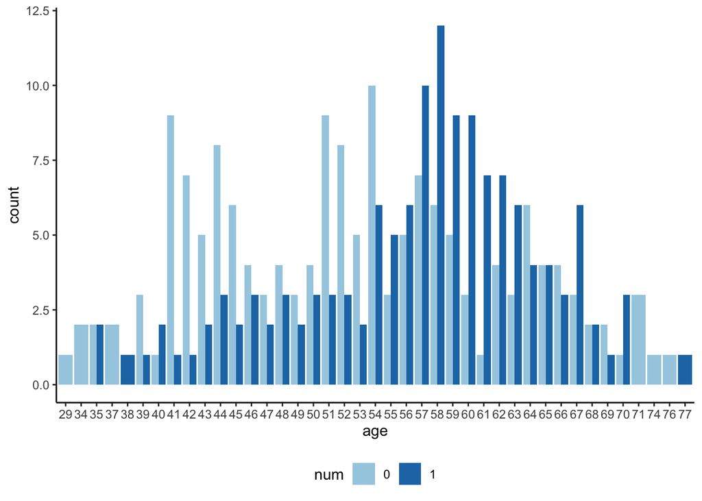

```r
ggplot(data=heart_problem, aes(x=age, y=count, fill=num)) +
  geom_bar(stat="identity", position=position_dodge())+
  scale_fill_brewer(palette="Paired")+
  theme_classic() + theme(legend.position="bottom")
```

## Distribution, outliers and correlation among continous variables

Confounding occurs when a variable associated with a dependent variable is also associated to another predictor variable Let us check if predictors variables (on the continous scale) are themselves correlated

The following plots indicate that resting blood pressure, cholesterol level and thalach have outliers. Analysis by disease status alo showed outlieres

**1. Outliers**

```r
 heart_data$num <- ifelse(heart_data$num==0, 0, 1)
 heart_data_expl <-heart_data[, .(age, trestbps,chol,thalach)]
 heart_data_expl[, id:=(1:nrow(heart_data_expl))]
 heartdataexpL= melt(heart_data_expl, id.vars =c('id'))
 a <- ggplot(heartdataexpL, aes(x=variable, y=value, color=variable)) +
  geom_boxplot() + ggtitle('data with outliers ' ) + theme(legend.position = "none")
```

Although there are many ways to deal with out liers, here I have excluded them from analysis

```r
out_chol     <- boxplot.stats(heart_data$chol)$out
out_tresbps <- boxplot.stats(heart_data$trestbps)$out
out_thalach <- boxplot.stats(heart_data$thalach)$out

out_chol_ind <- which(heart_data$chol %in% out_chol)
out_tresbps_ind <- which(heart_data$trestbps %in% out_tresbps)
out_thalach_ind <- which(heart_data$thalach %in% out_thalach)

 heart_datanew <-heart_data[-c(out_chol_ind,out_tresbps_ind,out_thalach_ind),]
```

Now let us plot

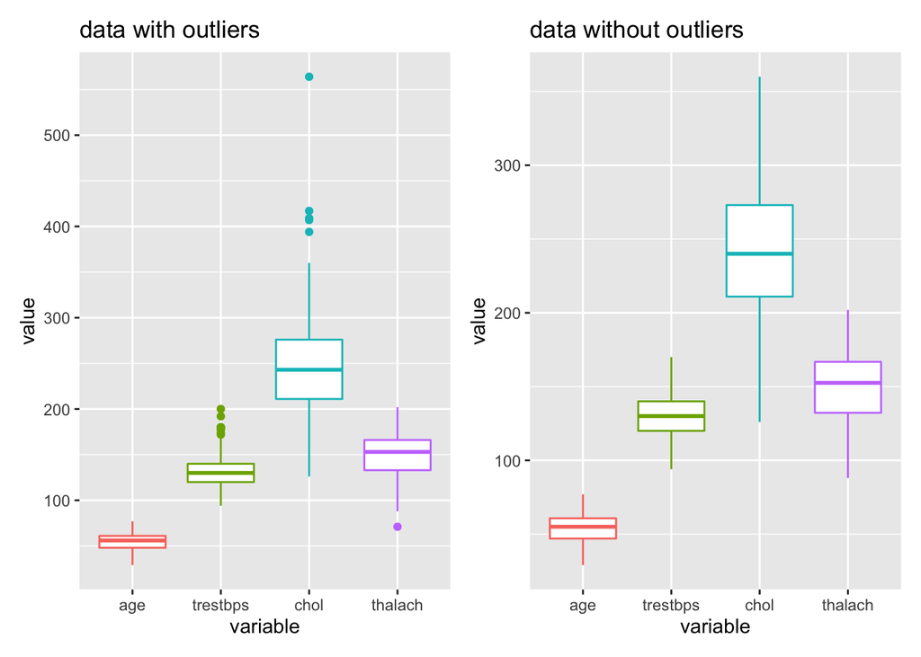

```r
 heart_data_expl <-heart_datanew[, .(age, trestbps,chol,thalach)]
 heart_data_expl[, id:=(1:nrow(heart_data_expl))]
 heartdataexpL= melt(heart_data_expl, id.vars =c('id'))
 b<-ggplot(heartdataexpL, aes(x=variable, y=value, color=variable)) +
   geom_boxplot() + ggtitle('data without outliers ' ) + theme(legend.position = "none")
 a+b
```

**2. Correlations and distributions by sex and disease status**

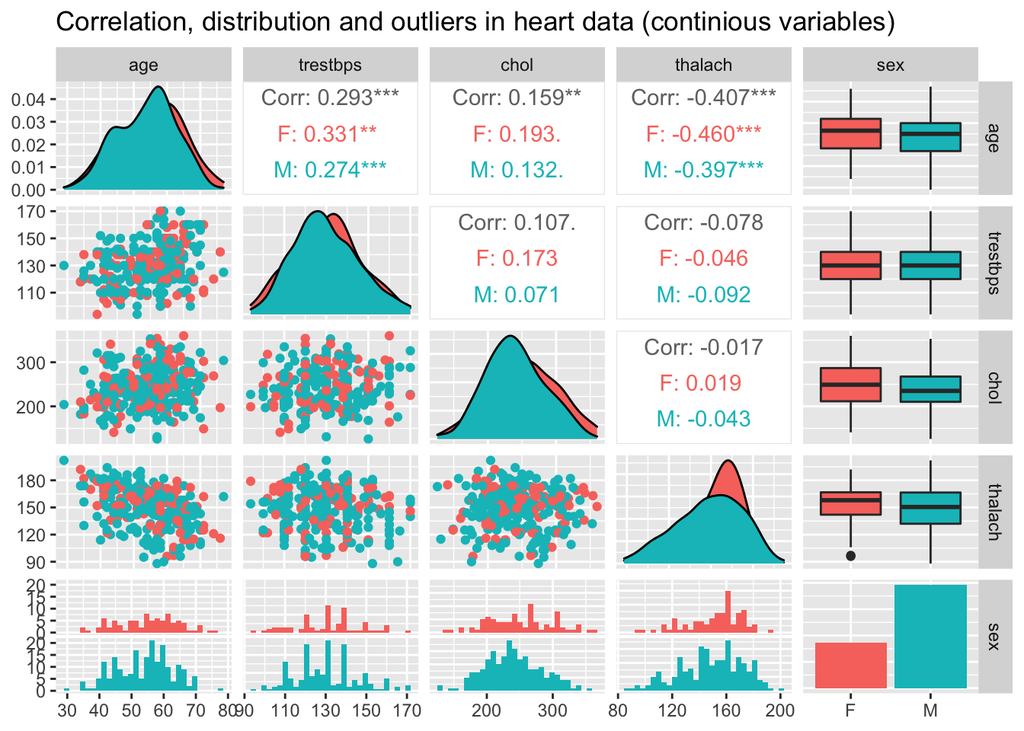

```r
corr_sex <-heart_datanew[, .(age, trestbps,chol,thalach, sex)]

corr_sex$sex = ifelse(corr_sex$sex==0, 'F', 'M')
ggpairs(data=corr_sex, title="Correlation, distribution and outliers in heart data (continious variables)",
              mapping=ggplot2::aes(colour = sex))
```

The following plot compared the distribution of variables by heart disease. Individuals with the problem tend to be in their 50’s, have lower maximum heart rate achieved, have higher cholesterol levels (probably because of out lairs).

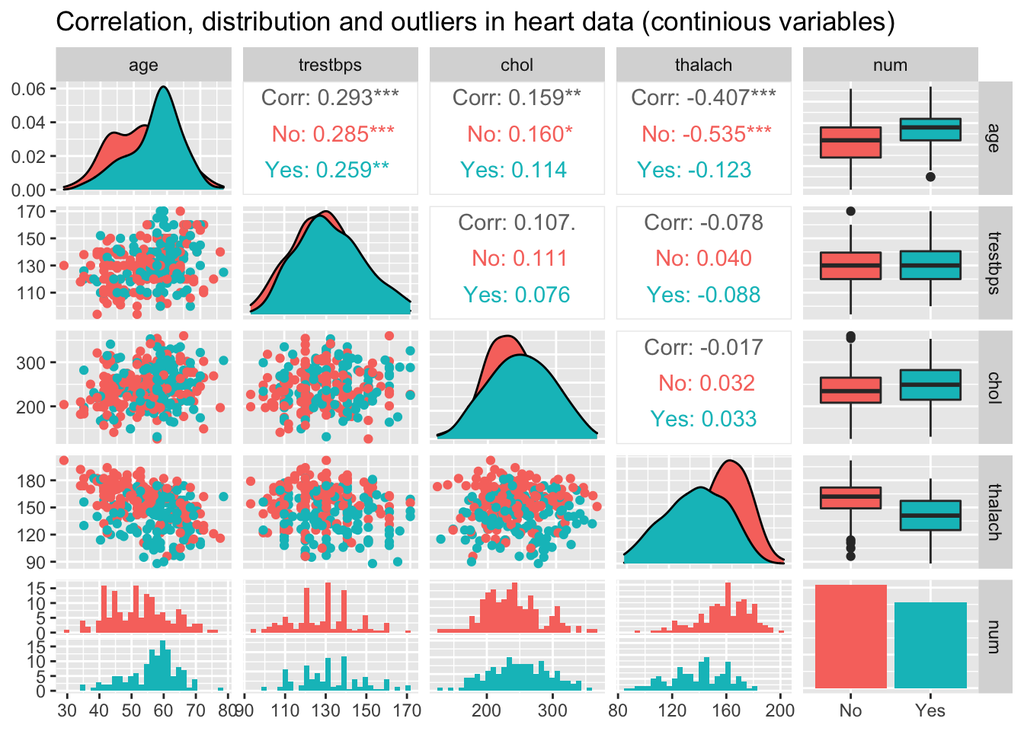

```r
corr_num <-heart_datanew[, .(age, trestbps,chol,thalach, num)]

corr_num$num = ifelse(corr_num$num==0, 'No', 'Yes')
ggpairs(corr_num, title="Correlation, distribution and outliers in heart data (continious variables)",
              mapping=ggplot2::aes(colour = num))
```

## Checking for confounders

Cheeking interaction between age and sex and heart disease?

The bar chart below captures the interaction between age, sex, and heart diseases. For females the disease pattern is not highly age dependent, although there is some clustering in those who are in their 50’s, the frequency is not that high. However, among males, the disease spans throughout men’s studied age, although it peaks in their 50’s. This probably indicates, presence of age and male sex interaction mediated by some third factor that needs further exploration.

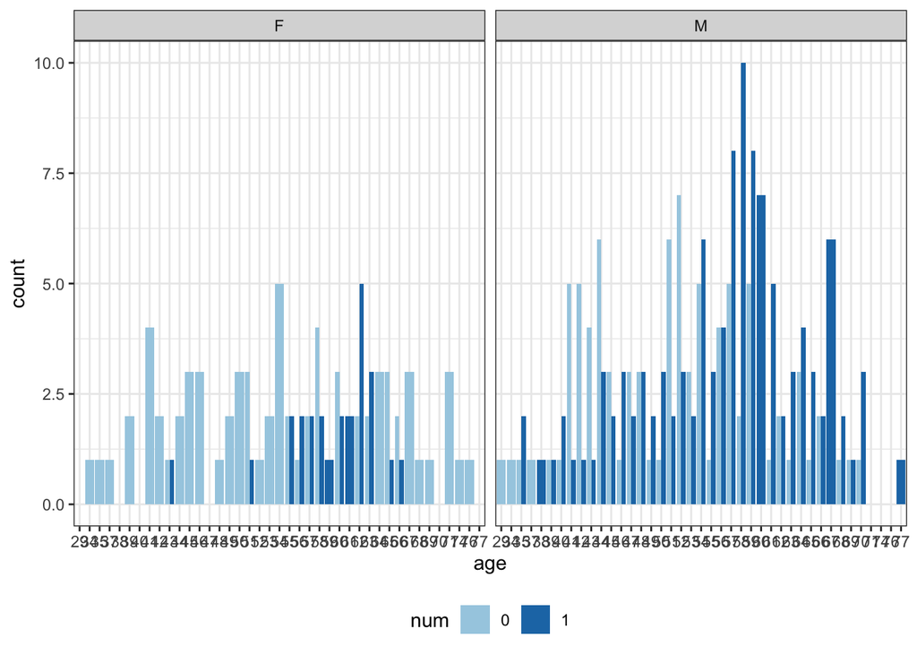

```r
heart_problem_absent <-heart_data[num==0, .(count = .N), by = .(age, sex)]
heart_problem_present <-heart_data[num==1, .(count = .N), by = .(age, sex)]
heart_problem_absent[, num:=0]; heart_problem_present[, num:=1]

heart_problem<-rbind(heart_problem_absent, heart_problem_present)
heart_problem$num <- as.factor(heart_problem$num);heart_problem$age <- as.factor(heart_problem$age)
heart_problem$sex <-ifelse (heart_problem$sex=='0', "F", 'M')

ggplot(data=heart_problem, aes(x=age, y=count, fill=num)) +
  geom_bar(stat="identity", position=position_dodge())+
  scale_fill_brewer(palette="Paired")+ facet_wrap(~sex)+
  theme_bw() + theme(legend.position="bottom")
```

## Check for sparse information in categorical variables

```r
heart_data <-heart_data[-c(out_chol_ind,out_tresbps_ind,out_thalach_ind),]  # using the updated data
tbl= table(heart_data$restecg, heart_data$num)
chisq.test(tbl)
```

```
##
##  Pearson's Chi-squared test
##
## data:  tbl
## X-squared = 9.0655, df = 2, p-value = 0.01075
```

```r
heart_data$restecg <-ifelse(heart_data$restecg=='0','0',' 1')   #regrouping again
table(heart_data$restecg, heart_data$num)
```

```
##
##       0  1
##    1 64 76
##   0  90 52
```

# Bayesian analysis

developing different models

```r
#heart_data <- data.table(heart_data)
heart_data[, id:=1:nrow(heart_data)]
#====================================
#=====Creating different models======================
formula1 <- num~1
formula2 = num~age+sex+chol+thalach + trestbps+fbs+restecg+
         exang+oldpeak+slope+ca
formula3 = num~age+sex+chol+thalach + trestbps+fbs+restecg+   # full model with random effects
         exang+oldpeak+slope+ca+ f(id, model="iid")
formula4= num~sex+chol+thalach + trestbps+fbs+                # full model minus age and restingecg excluded
         exang+oldpeak+slope+ca
formula5= num~sex+chol+thalach + fbs+
         exang+oldpeak+slope+ca                               # age and restingecg and resting bp excluded
```

Writing compact function to generate posterior estimates

```r
generate_bayesian_estimates <-  function(formula) {
           model= inla(formula,
                       data=heart_data,
                       family = "binomial", Ntrials = 1,
                       control.compute = list(dic= TRUE, cpo=TRUE),
                       num.threads = 2)
          return(summary(model))

         }
```

Call a function to run bayesian analysis

```r
 model1 <-generate_bayesian_estimates(formula1)
 model2 <-generate_bayesian_estimates(formula2)
 model3 <-generate_bayesian_estimates(formula3)
 model4 <-generate_bayesian_estimates(formula4)
 model5 <-generate_bayesian_estimates(formula5)
```

Return the outputs by un commenting the following chunks

```r
 # model1
 # model2
 # model3
 # model4
 # model5
```

# Conclusion and the way forward

Some observations were excluded from analysis due to outliers and special characters. We didn’t try using other data imputation methods and the impact of these exclusions needs to be checked although only few observations were trimmed in this case.